# Homework 2

Aditya Dube

Tuesday, May 16, 2023

# Question 1 Parts

## Loading Packages

```r
library(data.table)
library(tidyverse)
library(knitr)
library(arrow)
library(bench)
library(ggbeeswarm)
library(haven)
```

# Question 2 Parts

## Importing Dataset

```r
swiftSongs = read.csv(
  "https://raw.githubusercontent.com/dilernia/STA418-518/main/Data/swiftSongs.csv"
)
```

## Print a single table of the swiftSongs data containing the last 13 rows of the data using the slice_tail() function and the 30th through 34th columns using the select() function from the dplyr package.

```r
swiftSongs %>% dplyr::select(30:34) %>%
  slice_tail(n = 13) %>% kable()
```

| time_signature | duration_ms | explicit | track_name | track_number |
| --- | --- | --- | --- | --- |
| 4 | 250093 | FALSE | This Love | 11 |
| 4 | 248106 | FALSE | Tied Together with a Smile | 7 |
| 4 | 232106 | FALSE | Tim McGraw | 1 |
| 4 | 240773 | FALSE | Treacherous | 3 |
| 4 | 164801 | TRUE | Vigilante Shit | 8 |
| 4 | 191880 | FALSE | We Are Never Ever Getting Back Together | 8 |
| 4 | 212600 | FALSE | Welcome To New York | 1 |
| 4 | 234906 | FALSE | White Horse | 5 |
| 4 | 220440 | FALSE | Wildest Dreams | 9 |
| 4 | 231453 | FALSE | You Belong With Me | 6 |
| 4 | 171360 | FALSE | You Need To Calm Down | 14 |
| 4 | 262173 | FALSE | You’re Not Sorry | 9 |
| 4 | 194206 | FALSE | You’re On Your Own, Kid | 5 |

## Import data on Taylor Swift songs directly from the URL using the read.csv(), read_csv(), and the fread() functions, comparing the read times using the mark function from the bench package, storing the results of the mark function in an object called readTimes. Specify a minimum of 5 iterations in the mark function.

```r
readTimes <-
  mark(
    read.csv(
      "https://raw.githubusercontent.com/dilernia/STA418-518/main/Data/swiftSongs.csv"
    ),
    read_csv(
      "https://raw.githubusercontent.com/dilernia/STA418-518/main/Data/swiftSongs.csv",
      show_col_types = FALSE
    ),
    fread(
      "https://raw.githubusercontent.com/dilernia/STA418-518/main/Data/swiftSongs.csv"
    ),
    check = FALSE,
    min_iterations = 5
  )
ggObj <- plot(readTimes)

importTimes <- ggObj$data %>% mutate(expression =
                                       paste0(map_chr(str_split(expression, pattern = "[(]"), 1), "()"))
# Printing table
importTimes %>% arrange(desc(median)) %>%
  select(expression:mem_alloc) %>% distinct() %>% knitr::kable()
```

| expression | min | median | itr/sec | mem_alloc |
| --- | --- | --- | --- | --- |
| read_csv() | 191.2ms | 192.7ms | 5.186775 | 3.06MB |
| read.csv() | 47.5ms | 50.7ms | 15.713596 | 395.44KB |
| fread() | 12.5ms | 13ms | 69.856338 | 636.1KB |

## Create a violin plot to display the varying speeds of the three different functions for importing the data.

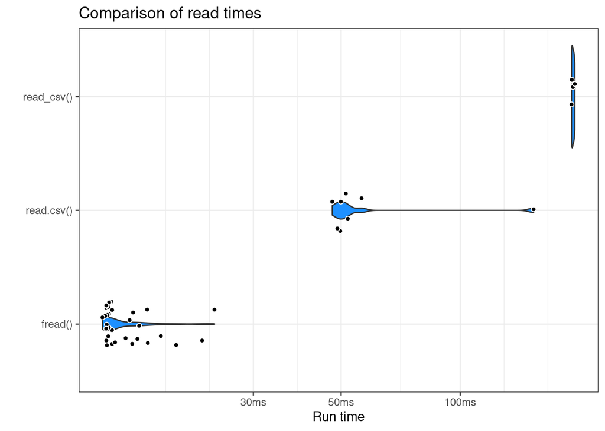

```r
importTimes %>% ggplot(aes(x = time, y = fct_reorder(expression, time))) +
  geom_violin(fill = "dodgerblue") +
  geom_jitter(
    height = 0.2,
    pch = 21,
    fill = "black",
    color = "white"
  ) +
  labs(title = "Comparison of read times", y = "", x = "Run time") +
  theme_bw()
```

## Based on the violin plot, which function was typically the fastest?

## Answer: fread() function was the fastest.

# Question 3 Parts

## Export data on Taylor Swift songs in the swiftSongs data set using the write.csv(), write_csv(), and the fwrite() functions, comparing the write times using the mark function from the bench package, storing the results of the mark function in an object called writeTimes. Specify a minimum of 5 iterations in the mark function.

```r
writeTimes <-
  mark(
    write.csv(swiftSongs, "swiftSongs.csv"),
    write_csv(swiftSongs, "swiftSongs.csv"),
    fwrite(swiftSongs, "swiftSongs.csv"),
    min_iterations = 5,
    check = FALSE,
    memory = FALSE
  )

ggObj <- plot(writeTimes)

exportTimes <- ggObj$data %>% mutate(expression =
                                       paste0(map_chr(str_split(
                                         expression, pattern = "[(]"
                                       ), 1), "()"))
# Printing table
exportTimes %>% arrange(desc(median)) %>%
  select(expression:mem_alloc) %>% distinct() %>% knitr::kable()
```

| expression | min | median | itr/sec | mem_alloc |
| --- | --- | --- | --- | --- |
| write_csv() | 13.29ms | 14.42ms | 68.44629 | NA |
| write.csv() | 5.52ms | 6.36ms | 157.56223 | NA |
| fwrite() | 2ms | 2.76ms | 355.32356 | NA |

## Create a violin plot to display the varying speeds of the three different functions for exporting the data.

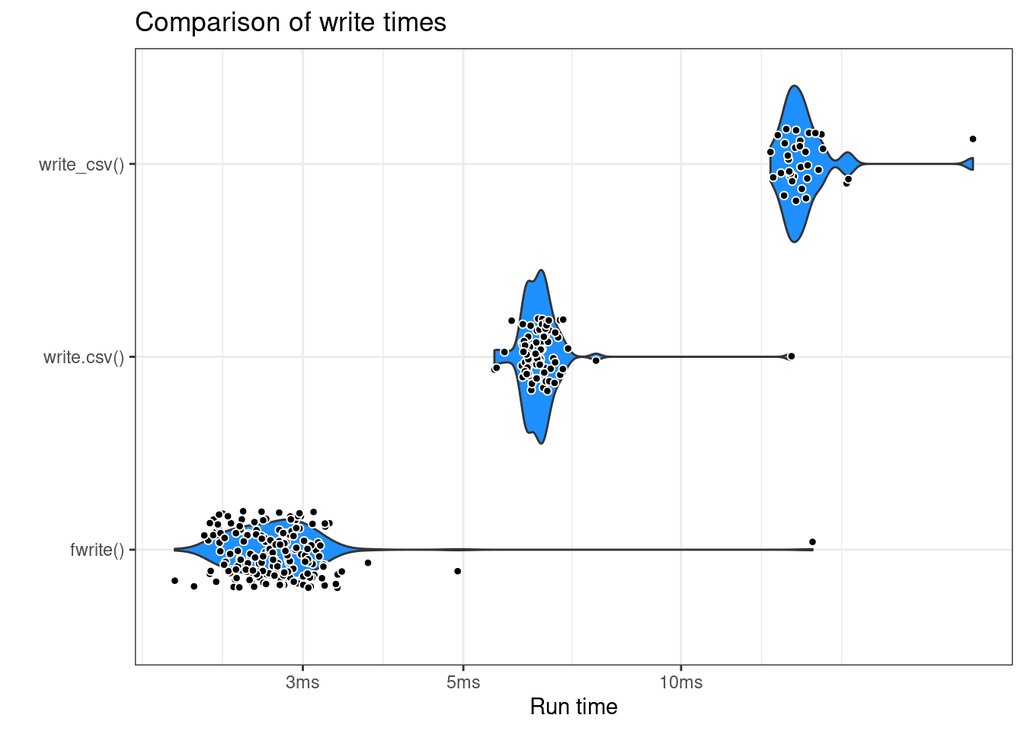

```r
exportTimes %>% ggplot(aes(x = time, y = fct_reorder(expression, time))) +
  geom_violin(fill = "dodgerblue") +
  geom_jitter(
    height = 0.2,
    pch = 21,
    fill = "black",
    color = "white"
  ) +
  labs(title = "Comparison of write times", y = "", x = "Run time") +
  theme_bw()
```

## Based on the violin plot, which function was typically the fastest?

## Answer: fwrite() is the fastest